# RISE Aim 2 - Enrollment

My Vu

11/15/2026

Total N of 119 in enrollment log with 8 screenfailed/rejected => N = 111

```
## # A tibble: 0 × 1
## # ℹ 1 variable: child_hashed_id <chr>
```

# Demographics

| **Characteristic** | **Overall** N = 111<sup>1</sup> | **6** N = 55<sup>1</sup> | **12** N = 56<sup>1</sup> |
| --- | --- | --- | --- |
| Gender |  |  |  |
| Female | 54 (48.6) | 31 (56.4) | 23 (41.1) |
| Male | 56 (50.5) | 23 (41.8) | 33 (58.9) |
| Other | 1 (0.9) | 1 (1.8) | 0 (0.0) |
| race |  |  |  |
| American Indian or Alaska Native | 0 (0.0) | 0 (0.0) | 0 (0.0) |
| Asian | 9 (8.3) | 5 (9.4) | 4 (7.1) |
| Black or African American | 2 (1.8) | 0 (0.0) | 2 (3.6) |
| Native Hawaiian or Other Pacific Islander | 0 (0.0) | 0 (0.0) | 0 (0.0) |
| White | 57 (52.3) | 28 (52.8) | 29 (51.8) |
| More than one race | 41 (37.6) | 20 (37.7) | 21 (37.5) |
| (Missing) | 2 | 2 | 0 |
| Ethnicity |  |  |  |
| Hispanic | 16 (14.7) | 8 (15.1) | 8 (14.3) |
| Not Hisp | 93 (85.3) | 45 (84.9) | 48 (85.7) |
| (Missing) | 2 | 2 | 0 |
| demographic__education_level2 |  |  |  |
| High school | 1 (0.9) | 0 (0.0) | 1 (1.8) |
| Associate (some college) | 3 (2.7) | 2 (3.7) | 1 (1.8) |
| Bachelor/College | 36 (32.7) | 17 (31.5) | 19 (33.9) |
| Graduate and Professional | 70 (63.6) | 35 (64.8) | 35 (62.5) |
| (Missing) | 1 | 1 | 0 |
| demographic__annual_income2 |  |  |  |
| < 50,000 | 11 (11.0) | 6 (12.8) | 5 (9.4) |
| 50,000 - 100,000 | 41 (41.0) | 19 (40.4) | 22 (41.5) |
| 101,000 - 200,000 | 25 (25.0) | 13 (27.7) | 12 (22.6) |
| > 200,000 | 23 (23.0) | 9 (19.1) | 14 (26.4) |
| (Missing) | 11 | 8 | 3 |
| Region |  |  |  |
| Northeast | 31 (28.4) | 17 (32.1) | 14 (25.0) |
| Midwest | 34 (31.2) | 14 (26.4) | 20 (35.7) |
| South | 26 (23.9) | 10 (18.9) | 16 (28.6) |
| West | 18 (16.5) | 12 (22.6) | 6 (10.7) |
| (Missing) | 2 | 2 | 0 |

<sup>1</sup> n (%)

MAKE SURE TO REMOVE LONG VIDEOS and TRIM the extra frames

# Geometric Social

Note on how outcome was derive:

1. Remove frames coded as “nobabyface”, “noface”, “none”, or “away”
2. Remove “left”, “right” frames with confidence < 85%
3. Use “left” vs “right” to code “target” vs “non-target” depending on the task and version. Calculate % looking for each social side as:

   % looking = (target) / (target + non-target)

   *left & right frames all need to have >= 85% confidence. A trial must have at least 33% usable data (i.e. left, right frames at 85% confidence) to be included.

## Data count

Number (and percent) of infants who viewed the task at all (2nd column, as % of consented sample with any icatcher data & in frame data , with sufficient usable data (3rd column, as % of infants who viewed the task), with fixation on a single side >80% of the task (4th column, as % of infants with usable data), and final N in the analytic dataset.

```
## # A tibble: 2 × 6
##   Age   Enrolled iCatcher_Ran iCatcher_Good Fixation  Usable
##   <fct> <chr>    <chr>        <chr>         <chr>      <int>
## 1 6     55       54 (98.2%)   51 (94.4%)    9 (17.6%)     42
## 2 12    56       53 (94.6%)   50 (94.3%)    3 (6.0%)      47
```

Video quality metrics by age group. Percentages reflect the mean across trials with iCatcher+ output only, calculated out of frames processed by iCatcher+. Trials where iCatcher+ produced no output are counted as missing trials.

| **Characteristic** | **6** N = 54<sup>1</sup> | **12** N = 53<sup>1</sup> |
| --- | --- | --- |
| max_trial |  |  |
| 10 | 54 (100%) | 53 (100%) |
| No face detected (%) | 0.0 (0.0, 2.7) | 0.0 (0.0, 2.1) |
| Unknown | 0 | 1 |
| Away looks (%) | 5.3 (1.1, 11.4) | 1.0 (0.0, 4.1) |
| Unknown | 0 | 1 |
| Low confidence left & right frames (%) | 9.9 (5.3, 14.6) | 11.3 (7.7, 16.2) |
| Unknown | 0 | 1 |

<sup>1</sup> n (%); Median (Q1, Q3)

**Median (IQR) number of test trials with usable data (final analytic)**

| **Characteristic** | **6** N = 42 | **12** N = 47 |
| --- | --- | --- |
| trial_num |  |  |
| Median (Q1, Q3) | 8.00 (7.00, 10.00) | 8.00 (7.00, 9.00) |
| Min, Max | 2.00, 10.00 | 3.00, 10.00 |

## Analysis

# VPC

8 versions, participants sees both object & face stimuli

Note on how outcome was derive:

1. Remove frames coded as “nobabyface”, “noface”, “none”, or “away”
2. Remove frames with with confidence < 85%
3. Use “left” vs “right” to code “target” vs “non-target” depending on the task and version. Calculate % looking for each novel side as:

   % looking = (target) / (target + non-target)

   *left & right frames all need to have >= 85% confidence. A trial must have at least 33% usable data (i.e. left, right frames at 85% confidence) to be included.

## Data count

Number (and percent) of infants who viewed the task at all (2nd column, as % of consented sample with any icatcher data & in frame data , with sufficient usable data (3rd column, as % of infants who viewed the task), with fixation on a single side >80% of the task (4th column, as % of infants with usable data), and final N in the analytic dataset.

```
## # A tibble: 2 × 6
##   Age   Enrolled iCatcher_Ran iCatcher_Good Fixation  Usable
##   <fct> <chr>    <chr>        <chr>         <chr>      <int>
## 1 6     55       50 (90.9%)   47 (94.0%)    6 (12.8%)     41
## 2 12    56       53 (94.6%)   47 (88.7%)    5 (10.6%)     42
```

Video quality metrics by age group. Percentages reflect the mean across trials with iCatcher+ output only, calculated out of frames processed by iCatcher+. Trials where iCatcher+ produced no output are counted as missing trials.

| **Characteristic** | **6** N = 50<sup>1</sup> | **12** N = 53<sup>1</sup> |
| --- | --- | --- |
| max_trial |  |  |
| 12 | 50 (100%) | 53 (100%) |
| No face detected (%) | 5.5 (0.9, 18.1) | 6.9 (1.7, 17.6) |
| Unknown | 2 | 3 |
| Away looks (%) | 21.9 (13.5, 28.2) | 16.7 (10.5, 26.8) |
| Unknown | 2 | 3 |
| Low confidence left & right frames (%) | 9.8 (6.4, 14.6) | 12.4 (9.3, 14.2) |
| Unknown | 2 | 3 |

<sup>1</sup> n (%); Median (Q1, Q3)

**Median (IQR) number of test trials with usable data (final analytic)**

| **Characteristic** | **6** N = 41 | **12** N = 42 |
| --- | --- | --- |
| trial_num |  |  |
| Median (Q1, Q3) | 6.00 (4.00, 6.00) | 5.00 (4.00, 6.00) |
| Min, Max | 1.00, 6.00 | 1.00, 6.00 |

## Analysis

effect of stimulus type overall, among 6 (Social - Non-social) and among 12-mos (Social - Non-social); p-values:

```
##  contrast              estimate     SE  df t.ratio p.value
##  (Non-social) - Social -0.00671 0.0163 340  -0.411  0.6815
##
## Results are averaged over the levels of: Age
## Degrees-of-freedom method: kenward-roger
```

```
## Age = 6:
##  contrast              estimate     SE  df t.ratio p.value
##  (Non-social) - Social -0.01636 0.0229 339  -0.715  0.4749
##
## Age = 12:
##  contrast              estimate     SE  df t.ratio p.value
##  (Non-social) - Social  0.00294 0.0229 339   0.128  0.8979
##
## Degrees-of-freedom method: kenward-roger
```

# Prediction

2 versions LthenR vs RthenL

Note on how outcome was derive:

1. Remove frames coded as “nobabyface”, “noface”, “none”, or “away”
2. Remove “left”, “right” frames with confidence < 85%
3. Use “left” vs “right” to code “target” vs “non-target” depending on the task and version. For each test trials for each block (2-8) and (10-16), an AEM = if participant looks at target at all during critical window.

For each block, compute total trials per participant, then calculate proportion of AEM trials as final outcome.

## Data count

Number (and percent) of infants who viewed the task at all (2nd column, as % of consented sample with any icatcher data & in frame data , with sufficient usable data (3rd column, as % of infants who viewed the task), with fixation on a single side >80% of the task (4th column, as % of infants with usable data), and final N in the analytic dataset.

```
## # A tibble: 2 × 6
##   Age   Enrolled iCatcher_Ran iCatcher_Good Fixation Usable
##   <fct> <chr>    <chr>        <chr>         <chr>     <int>
## 1 6     55       52 (94.5%)   51 (98.1%)    NA (NA%)     51
## 2 12    56       51 (91.1%)   48 (94.1%)    NA (NA%)     48
```

Video quality metrics by age group. Percentages reflect the mean across trials with iCatcher+ output only, calculated out of frames processed by iCatcher+. Trials where iCatcher+ produced no output are counted as missing trials.

| **Characteristic** | **6** N = 52<sup>1</sup> | **12** N = 51<sup>1</sup> |
| --- | --- | --- |
| max_trial |  |  |
| 16 | 52 (100%) | 51 (100%) |
| No face detected (%) | 0.0 (0.0, 3.4) | 0.0 (0.0, 5.8) |
| Away looks (%) | 9.6 (1.7, 21.6) | 5.8 (1.0, 13.5) |
| Low confidence left & right frames (%) | 18.0 (10.8, 26.0) | 22.1 (9.1, 35.1) |

<sup>1</sup> n (%); Median (Q1, Q3)

Filter out trials 1 and 9. Participants must have at least 1 AEM trial in Block 2. Must have usable data for at least 2 trials in block 1 for block 1 outcome to be included. Similarly for block 2.

**Median (IQR) number of test trials with usable data (final analytic)**

| **Characteristic** | **6** N = 37 | **12** N = 35 |
| --- | --- | --- |
| n |  |  |
| Median (Q1, Q3) | 10.00 (7.00, 12.00) | 10.00 (8.00, 13.00) |
| Min, Max | 4.00, 14.00 | 3.00, 14.00 |

```
## [1] 37
```

```
## [1] 35
```

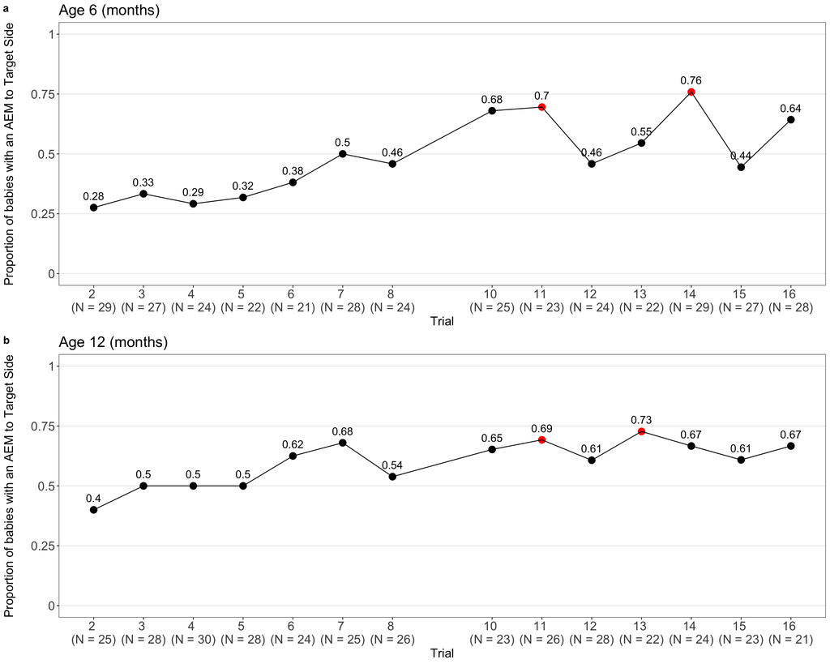

Age 6 estimate is significant for being < 0.5 - so just a note.

# AV

Note on how outcome was derive:

1. Remove frames coded as “nobabyface”, “noface”, “none”, or “away”
2. Remove “left”, “right” frames with confidence < 85%
3. Use “left” vs “right” to code “target” vs “non-target” depending on the task and version. Calculate % looking for each synch side as:

   % looking = (target) / (target + non-target)

   *left & right frames all need to have >= 85% confidence. A trial must have at least 33% usable data (i.e. left, right frames at 85% confidence) to be included.

## Data count

Number (and percent) of infants who viewed the task at all (2nd column, as % of consented sample with any icatcher data & in frame data , with sufficient usable data (3rd column, as % of infants who viewed the task), with fixation on a single side >80% of the task (4th column, as % of infants with usable data), and final N in the analytic dataset.

```
## # A tibble: 2 × 6
##   Age   Enrolled iCatcher_Ran iCatcher_Good Fixation   Usable
##   <fct> <chr>    <chr>        <chr>         <chr>       <int>
## 1 6     55       50 (90.9%)   47 (94.0%)    11 (23.4%)     36
## 2 12    56       54 (96.4%)   50 (92.6%)    10 (20.0%)     40
```

Video quality metrics by age group. Percentages reflect the mean across trials with iCatcher+ output only, calculated out of frames processed by iCatcher+. Trials where iCatcher+ produced no output are counted as missing trials.

| **Characteristic** | **6** N = 50<sup>1</sup> | **12** N = 54<sup>1</sup> |
| --- | --- | --- |
| max_trial |  |  |
| 6 | 50 (100%) | 54 (100%) |
| No face detected (%) | 2.2 (0.3, 18.0) | 3.0 (0.1, 8.5) |
| Away looks (%) | 11.9 (7.5, 20.3) | 9.5 (4.7, 22.5) |
| Low confidence left & right frames (%) | 10.4 (6.5, 15.0) | 11.7 (9.5, 18.1) |

<sup>1</sup> n (%); Median (Q1, Q3)

**Median (IQR) number of test trials with usable data (final analytic)**

| **Characteristic** | **6** N = 36 | **12** N = 40 |
| --- | --- | --- |
| trial_num |  |  |
| Median (Q1, Q3) | 6.00 (5.00, 6.00) | 6.00 (5.00, 6.00) |
| Min, Max | 3.00, 6.00 | 1.00, 6.00 |

## Analysis

# Word recognition

How outcome was derived:

Example of foot and milk (paired).

The word foot is the target in trial 1 and the distractor at trial 9. the difference for foot = % looking at the word foot in trial 1 - % looking at the word foot in trial 9. Simplified:

foot_diff = trial1_target - trial9_distractor = trial1_target - (1 - trial9_target) = trial1_target + trial9_target - 1

But remember that the words are paired (these pairs are always shown together): foot ~ milk banana ~ hair hand ~ yogurt eyes ~ cookie mouth ~ apple

The word milk then the target at trial 9 but the distractor at trial 1. So then for “milk”: the difference for milk = % looking at the word milk in trial 9 - % looking at the word milk in trial 1. Simplified:

milk_diff = trial9_target – trial1_distractor = trial9_target - (1 - trial1_target) = trial9_target + trial1_target - 1

And then if you look at the math, foot_diff comes out to be the same as milk_diff (trial1_target + trial9_target – 1), so we just use this word-paired data once & we have 5 pairs in total. Kiddos will have up to 5 rows of final difference score.

The same thing repeats for trial 11 and trial 19.

Then the final data for foot ~ milk is: average %target - average %distractor = average of trial1_target & trial11_target - average of trial9_distractor & trial19_distractor.

## Timecourse

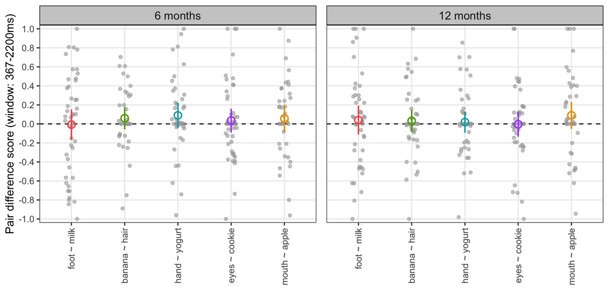

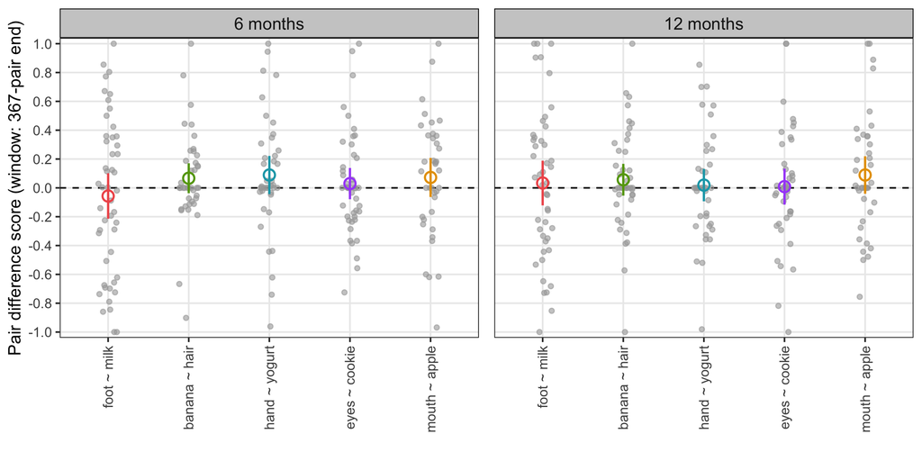

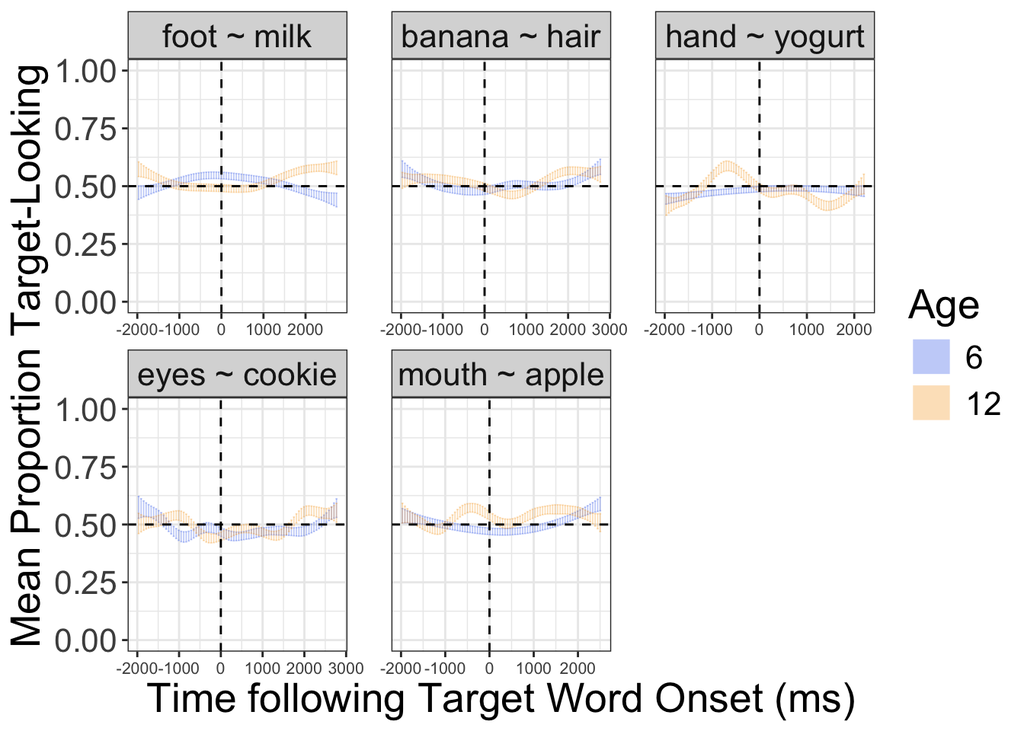

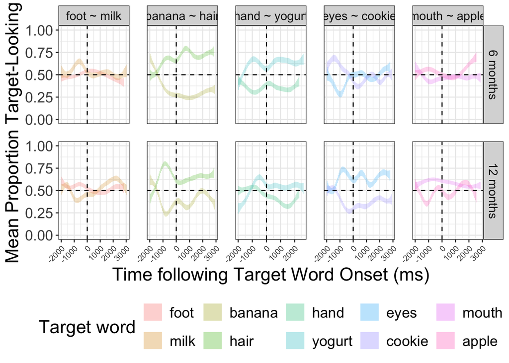

# Analysis

Number (and percent) of infants who viewed the task at all (2nd column, as % of consented sample with any icatcher data & in frame data , with sufficient usable data (3rd column, as % of infants who viewed the task), with fixation on a single side >80% of the task (4th column, as % of infants with usable data), and final N in the analytic dataset.

```
## # A tibble: 2 × 6
##   Age   Enrolled iCatcher_Ran iCatcher_Good Fixation   Usable
##   <fct> <chr>    <chr>        <chr>         <chr>       <int>
## 1 6     55       53 (96.4%)   52 (98.1%)    13 (25.0%)     39
## 2 12    56       53 (94.6%)   50 (94.3%)    5 (10.0%)      45
```

Video quality metrics by age group. Percentages reflect the mean across trials with iCatcher+ output only, calculated out of frames processed by iCatcher+. Trials where iCatcher+ produced no output are counted as missing trials.

| **Characteristic** | **6** N = 53<sup>1</sup> | **12** N = 53<sup>1</sup> |
| --- | --- | --- |
| max_trial |  |  |
| 20 | 53 (100%) | 53 (100%) |
| No face detected (%) | 0.8 (0.0, 4.5) | 0.4 (0.0, 4.9) |
| Away looks (%) | 11.3 (6.9, 22.3) | 4.1 (0.5, 15.5) |
| Low confidence left & right frames (%) | 10.0 (7.0, 15.0) | 10.1 (7.1, 19.1) |

<sup>1</sup> n (%); Median (Q1, Q3)

**Median (IQR) number of test trials with usable data (final analytic)**

| **Characteristic** | **6** N = 39 | **12** N = 45 |
| --- | --- | --- |
| trial_num |  |  |
| Median (Q1, Q3) | 12.00 (9.00, 14.00) | 11.00 (8.00, 15.00) |
| Min, Max | 4.00, 17.00 | 2.00, 19.00 |

Final word recognition N (lower due to % target or % distractor is not available for the “difference” calculation)

**Median (IQR) number of test trials with usable data (final analytic)**

| **Characteristic** | **6** N = 35 | **12** N = 40 |
| --- | --- | --- |
| n |  |  |
| Median (Q1, Q3) | 3.00 (2.00, 4.00) | 3.00 (2.00, 4.00) |
| Min, Max | 1.00, 5.00 | 1.00, 5.00 |

# Numeracy

4 versions, participants sees ONLY small constant in 2 versions, and ONLY large constant in the other 2 versions.

Note on how outcome was derive:

1. Remove frames coded as “nobabyface”, “noface”, “none”, or “away”
2. Remove “left”, “right” frames with confidence < 85%
3. Use “left” vs “right” to code “target” vs “non-target” depending on the task and version. Calculate % looking for each alternating/changing side as:

   % looking = (target) / (target + non-target)

   *left & right frames all need to have >= 85% confidence. A trial must have at least 33% usable data (i.e. left, right frames at 85% confidence) to be included.

## Data count

Number (and percent) of infants who viewed the task at all (2nd column, as % of consented sample with any icatcher data & in frame data , with sufficient usable data (3rd column, as % of infants who viewed the task), with fixation on a single side >80% of the task (4th column, as % of infants with usable data), and final N in the analytic dataset.

```
## # A tibble: 2 × 6
##   Age   Enrolled iCatcher_Ran iCatcher_Good Fixation   Usable
##   <fct> <chr>    <chr>        <chr>         <chr>       <int>
## 1 6     55       49 (89.1%)   45 (91.8%)    18 (40.0%)     27
## 2 12    56       52 (92.9%)   43 (82.7%)    12 (27.9%)     31
```

Video quality metrics by age group. Percentages reflect the mean across trials with iCatcher+ output only, calculated out of frames processed by iCatcher+. Trials where iCatcher+ produced no output are counted as missing trials.

| **Characteristic** | **6** N = 49<sup>1</sup> | **12** N = 52<sup>1</sup> |
| --- | --- | --- |
| max_trial |  |  |
| 4 | 49 (100%) | 52 (100%) |
| No face detected (%) | 7.6 (0.8, 24.0) | 6.4 (1.7, 18.7) |
| Away looks (%) | 16.1 (4.3, 31.1) | 19.5 (12.8, 34.6) |
| Low confidence left & right frames (%) | 10.3 (6.6, 15.4) | 15.3 (10.8, 17.3) |

<sup>1</sup> n (%); Median (Q1, Q3)

**Median (IQR) number of test trials with usable data (final analytic)**

| **Characteristic** | **6** N = 27 | **12** N = 31 |
| --- | --- | --- |
| trial_num |  |  |
| Median (Q1, Q3) | 4.00 (3.00, 4.00) | 3.00 (2.00, 4.00) |
| Min, Max | 1.00, 4.00 | 1.00, 4.00 |

## Analysis

# Helper Hinderer

8 versions, participants sees both helper and hinderer.

Note on how outcome was derive:

1. Remove frames coded as “nobabyface”, “noface”, “none”, or “away”
2. Remove “left”, “right” frames with confidence < 85%
3. Use “left” vs “right” to code “target” vs “non-target” depending on the task and version. Calculate % looking for each helper side as:

   % looking = (target) / (target + non-target)

   *left & right frames all need to have >= 85% confidence. A trial must have at least 33% usable data (i.e. left, right frames at 85% confidence) to be included.

## Data count

Number (and percent) of infants who viewed the task at all (2nd column, as % of consented sample with any icatcher data & in frame data , with sufficient usable data (3rd column, as % of infants who viewed the task), with fixation on a single side >80% of the task (4th column, as % of infants with usable data), and final N in the analytic dataset.

```
## # A tibble: 2 × 6
##   Age   Enrolled iCatcher_Ran iCatcher_Good Fixation  Usable
##   <fct> <chr>    <chr>        <chr>         <chr>      <int>
## 1 6     55       50 (90.9%)   26 (52.0%)    3 (11.5%)     23
## 2 12    56       48 (85.7%)   37 (77.1%)    7 (18.9%)     30
```

Video quality metrics by age group. Percentages reflect the mean across trials with iCatcher+ output only, calculated out of frames processed by iCatcher+. Trials where iCatcher+ produced no output are counted as missing trials.

| **Characteristic** | **6** N = 50<sup>1</sup> | **12** N = 48<sup>1</sup> |
| --- | --- | --- |
| max_trial |  |  |
| 14 | 50 (100%) | 48 (100%) |
| No face detected (%) | 13.5 (4.9, 23.5) | 6.8 (1.4, 14.0) |
| Away looks (%) | 22.9 (12.3, 37.0) | 14.4 (8.8, 24.1) |
| Low confidence left & right frames (%) | 10.3 (7.9, 13.6) | 13.5 (10.6, 15.8) |

<sup>1</sup> n (%); Median (Q1, Q3)

**Median (IQR) number of test trials with usable data (final analytic)**

| **Characteristic** | **6** N = 23 | **12** N = 30 |
| --- | --- | --- |
| trial_num |  |  |
| Median (Q1, Q3) | 2.00 (1.00, 2.00) | 2.00 (1.00, 2.00) |
| Min, Max | 1.00, 2.00 | 1.00, 2.00 |

For each block, a participant was required to have at least one usable helper trial and at least one hinderer trial (Block 1: trials 1–6; Block 2: trials 8–13), where usable trials were defined as having at least 33% of frames with valid iCatcher+ detections at ≥85% confidence.

**Median (IQR) number of test trials with usable data (final analytic)**

| **Characteristic** | **6** N = 23 | **12** N = 30 |
| --- | --- | --- |
| n |  |  |
| Median (Q1, Q3) | 2.00 (1.00, 2.00) | 2.00 (1.00, 2.00) |
| Min, Max | 1.00, 2.00 | 1.00, 2.00 |

## Analysis

# Figures

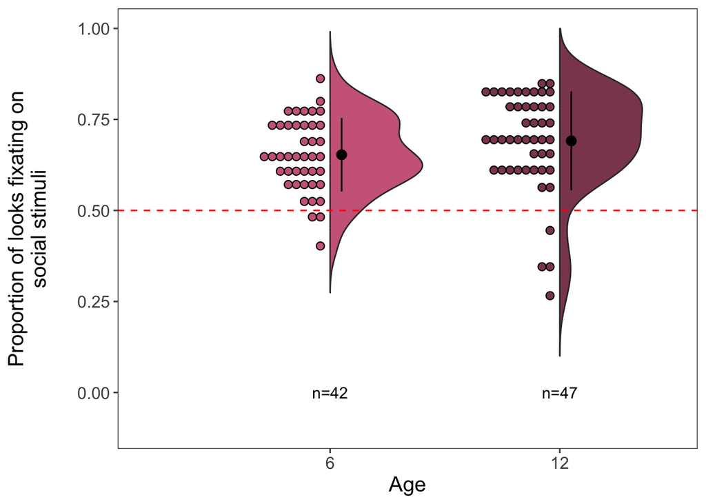

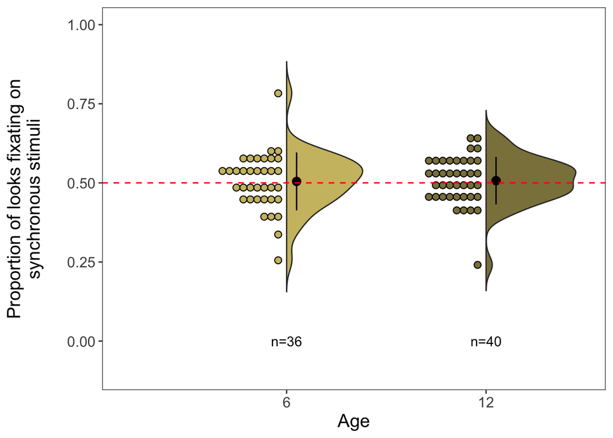

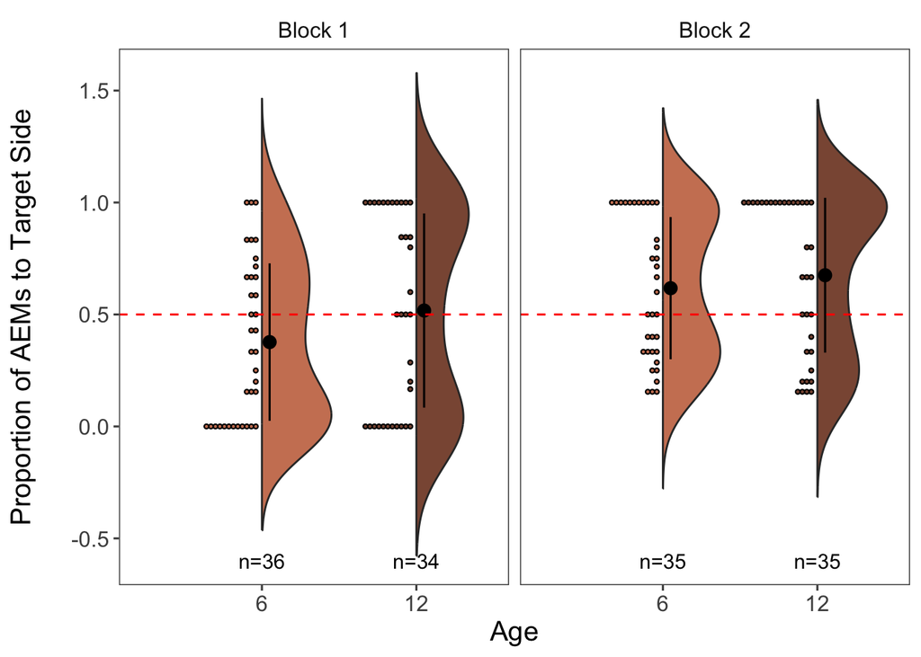

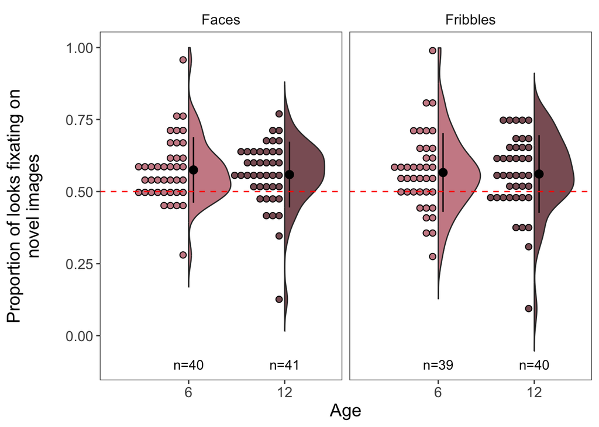

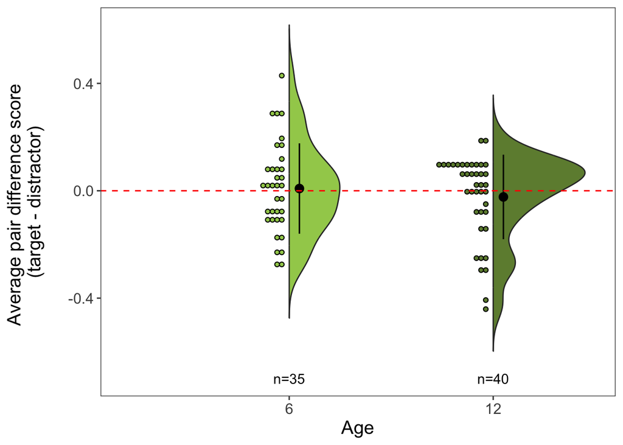

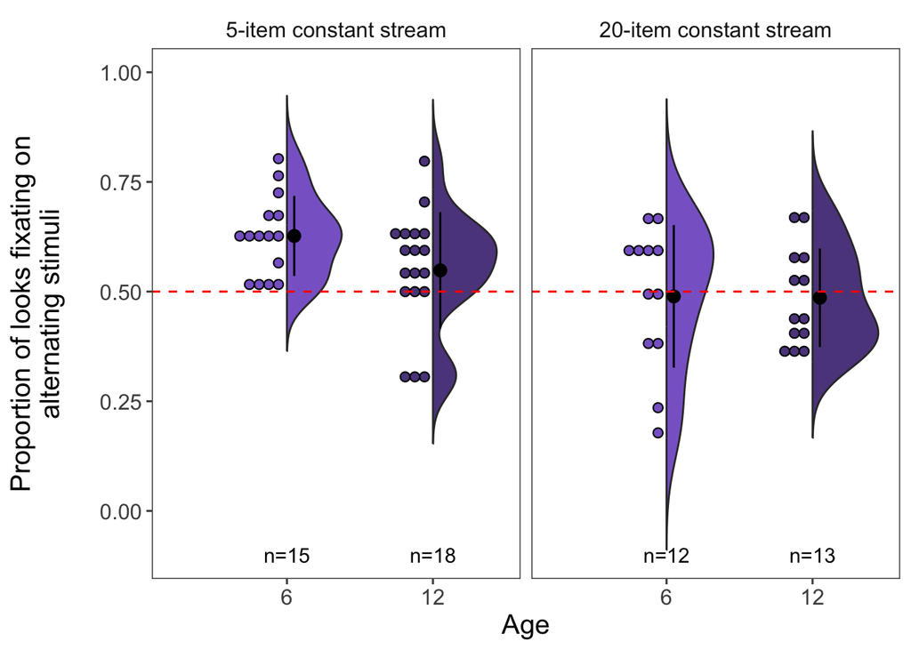

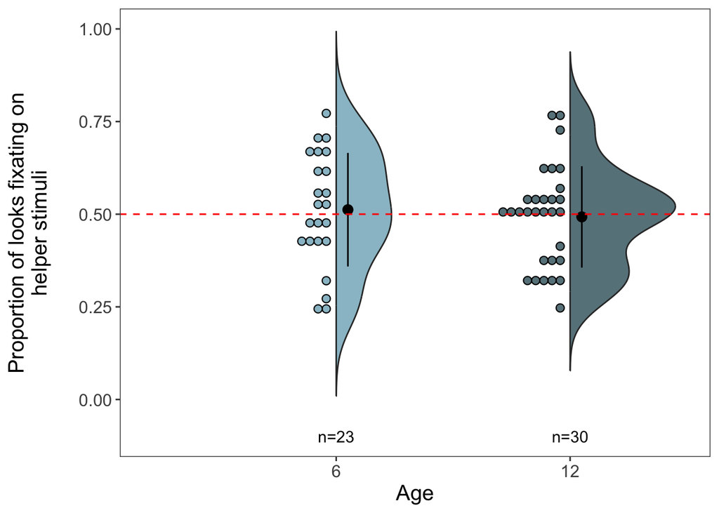

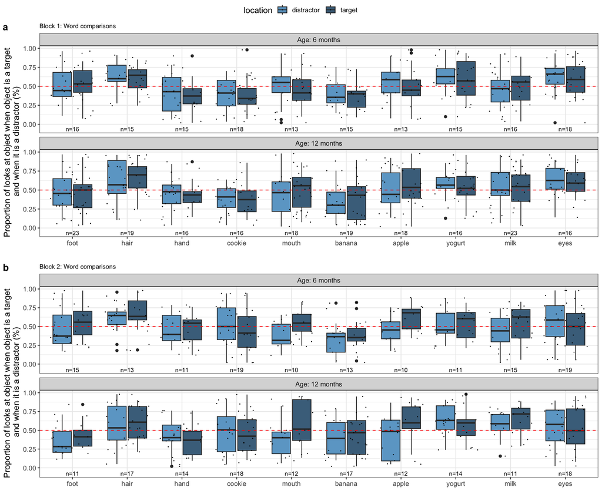

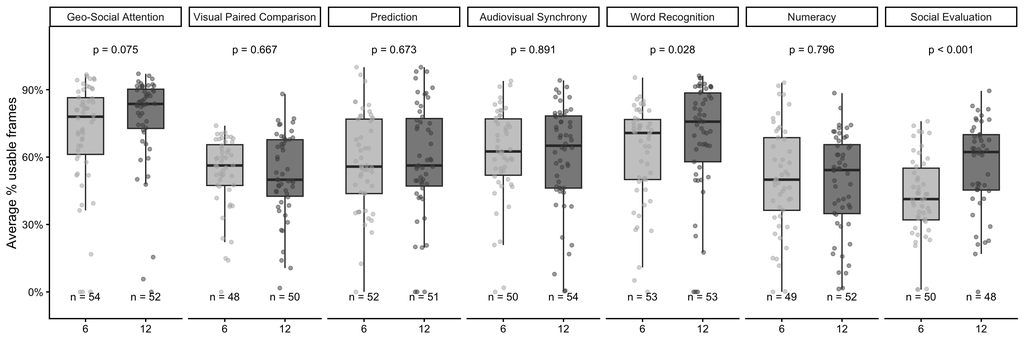

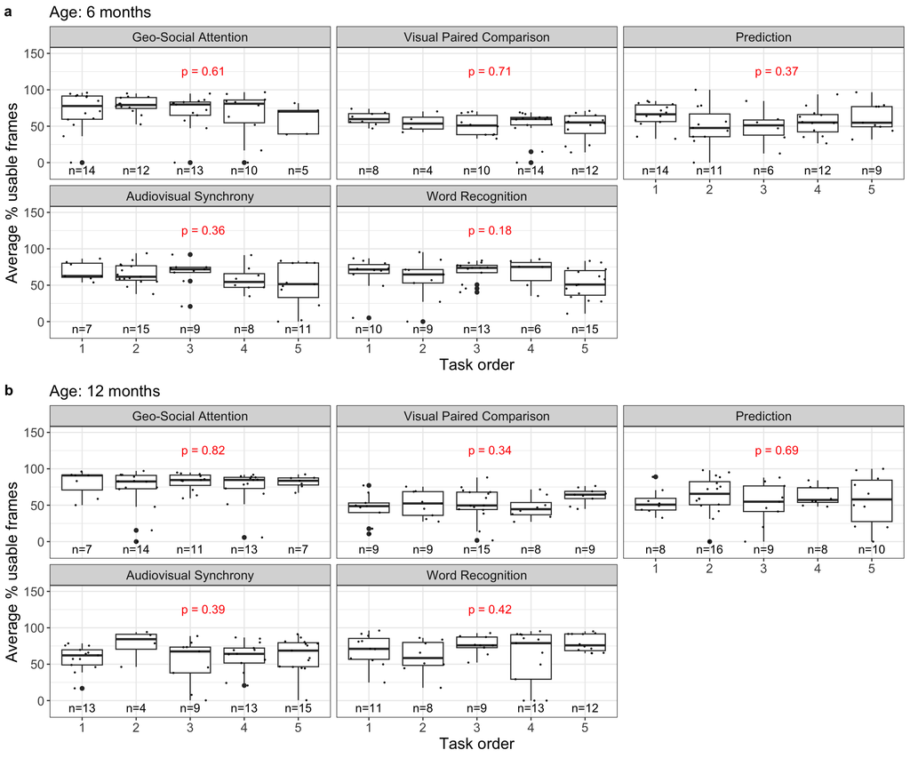

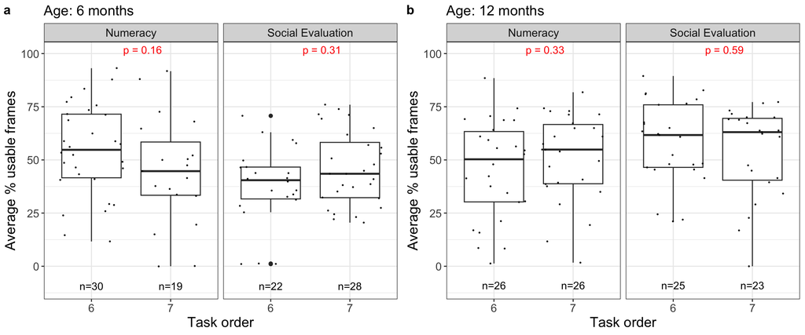

# Final Tables

Table 3: Data quality metrics from iCatcher+ output across all administered trials.

| Task | N trials (QC) | N valid iCatcher+ (6) | N valid iCatcher+ (12) | N 0% completion (6) | N 0% completion (12) | Median (IQR) % no-face frames (6) | Median (IQR) % no-face frames (12) | Median (IQR) % away frames (6) | Median (IQR) % away frames (12) | Median (IQR) % low-confidence frames (6) | Median (IQR) % low-confidence frames (12) |
| --- | --- | --- | --- | --- | --- | --- | --- | --- | --- | --- | --- |
| Geo-Social Attention | 10 | 54 (98.2%) | 53 (94.6%) | 0 (0.0%) | 1 (1.9%) | 0.0 (0.0, 2.7) | 0.0 (0.0, 2.1) | 5.3 (1.1, 11.4) | 1.0 (0.0, 4.1) | 9.9 (5.3, 14.6) | 11.3 (7.7, 16.2) |
| Visual Paired Comparison (VPC) | 12 | 50 (90.9%) | 53 (94.6%) | 2 (4.0%) | 3 (5.7%) | 5.5 (0.9, 18.1) | 6.9 (1.7, 17.6) | 21.9 (13.5, 28.2) | 16.7 (10.5, 26.8) | 9.8 (6.4, 14.6) | 12.4 (9.3, 14.2) |
| Prediction | 16 | 52 (94.5%) | 51 (91.1%) | 0 (0.0%) | 0 (0.0%) | 0.0 (0.0, 3.4) | 0.0 (0.0, 5.8) | 9.6 (1.7, 21.6) | 5.8 (1.0, 13.5) | 18.0 (10.8, 26.0) | 22.1 (9.1, 35.1) |
| Audiovisual Synchrony | 6 | 50 (90.9%) | 54 (96.4%) | 0 (0.0%) | 0 (0.0%) | 2.2 (0.3, 18.0) | 3.0 (0.1, 8.5) | 11.9 (7.5, 20.3) | 9.5 (4.7, 22.5) | 10.4 (6.5, 15.0) | 11.7 (9.5, 18.1) |
| Word Comprehension | 20 | 53 (96.4%) | 53 (94.6%) | 0 (0.0%) | 0 (0.0%) | 0.8 (0.0, 4.5) | 0.4 (0.0, 4.9) | 11.3 (6.9, 22.3) | 4.1 (0.5, 15.5) | 10.0 (7.0, 15.0) | 10.1 (7.1, 19.1) |
| Numeracy | 4 | 49 (89.1%) | 52 (92.9%) | 0 (0.0%) | 0 (0.0%) | 7.6 (0.8, 24.0) | 6.4 (1.7, 18.7) | 16.1 (4.3, 31.1) | 19.5 (12.8, 34.6) | 10.3 (6.6, 15.4) | 15.3 (10.8, 17.3) |
| Social Evaluation | 14 | 50 (90.9%) | 48 (85.7%) | 0 (0.0%) | 0 (0.0%) | 13.5 (4.9, 23.5) | 6.8 (1.4, 14.0) | 22.9 (12.3, 37.0) | 14.4 (8.8, 24.1) | 10.3 (7.9, 13.6) | 13.5 (10.6, 15.8) |

Table 4: Participant retention across data quality and inclusion criteria steps, by task and age group.

| Task | Analytic trials/word pairs | N valid iCatcher+ (6) | N valid iCatcher+ (12) | N ≥33% usable frames (6) | N ≥33% usable frames (12) | N side bias (6) | N side bias (12) | N final analytic sample (6) | N final analytic sample (12) | Median (IQR) trials (6) | Median (IQR) trials (12) |
| --- | --- | --- | --- | --- | --- | --- | --- | --- | --- | --- | --- |
| Geo-Social Attention | 10 | 54 (98.2%) | 53 (94.6%) | 51 (94.4%) | 50 (94.3%) | 9 (17.6%) | 3 (6.0%) | 42 | 47 | 8.0 (7.0, 9.8) | 8.0 (7.0, 9.0) |
| Visual Paired Comparison | 6 | 50 (90.9%) | 53 (94.6%) | 47 (94.0%) | 47 (88.7%) | 6 (12.8%) | 5 (10.6%) | 41 | 42 | 6.0 (4.0, 6.0) | 5.0 (4.0, 6.0) |
| Prediction | 14 | 52 (94.5%) | 51 (91.1%) | 51 (98.1%) | 48 (94.1%) | — | — | 37 | 35 | 10.0 (7.0, 12.0) | 10.0 (8.0, 12.5) |
| Audiovisual Synchrony | 6 | 50 (90.9%) | 54 (96.4%) | 47 (94.0%) | 50 (92.6%) | 11 (23.4%) | 10 (20.0%) | 36 | 40 | 6.0 (5.0, 6.0) | 6.0 (5.0, 6.0) |
| Word Comprehension | 5 | 53 (96.4%) | 53 (94.6%) | 52 (98.1%) | 50 (94.3%) | 13 (25.0%) | 5 (10.0%) | 35 | 40 | 3.0 (2.0, 4.0) | 3.0 (2.0, 4.0) |
| Numeracy | 4 | 49 (89.1%) | 52 (92.9%) | 45 (91.8%) | 43 (82.7%) | 18 (40.0%) | 12 (27.9%) | 27 | 31 | 4.0 (3.0, 4.0) | 3.0 (2.5, 4.0) |
| Social Evaluation | 2 | 50 (90.9%) | 48 (85.7%) | 26 (52.0%) | 37 (77.1%) | 3 (11.5%) | 7 (18.9%) | 23 | 30 | 2.0 (1.0, 2.0) | 2.0 (1.0, 2.0) |

Summary of mixed model estimates

| Task | Overall Estimate (95% CI) | Overall P-value | Age 6 Estimate (95% CI) | Age 6 P-value | Age 12 Estimate (95% CI) | Age 12 P-value | Age 12 - Age 6 Estimate (95% CI) | Age 12 - Age 6 P-value |
| --- | --- | --- | --- | --- | --- | --- | --- | --- |
| Geo-Social Attention | 0.68 (0.63, 0.73) | < 0.001 | 0.66 (0.60, 0.72) | < 0.001 | 0.70 (0.64, 0.76) | < 0.001 | 0.04 (-0.01, 0.09) | 0.127 |
| VPC Social (face) | 0.57 (0.53, 0.61) | 0.002 | 0.57 (0.53, 0.61) | 0.002 | 0.57 (0.53, 0.61) | 0.003 | -0.00 (-0.05, 0.04) | 0.911 |
| VPC Non-social (fribbles) | 0.56 (0.53, 0.60) | 0.004 | 0.56 (0.51, 0.60) | 0.016 | 0.57 (0.53, 0.62) | 0.003 | 0.02 (-0.03, 0.07) | 0.504 |
| Prediction Block 1 | 0.45 (0.36, 0.53) | 0.227 | 0.38 (0.26, 0.50) | 0.044 | 0.52 (0.39, 0.64) | 0.778 | 0.14 (-0.03, 0.31) | 0.108 |
| Prediction Block 2 | 0.65 (0.56, 0.73) | 0.001 | 0.62 (0.50, 0.74) | 0.059 | 0.68 (0.55, 0.80) | 0.005 | 0.06 (-0.11, 0.23) | 0.507 |
| AV Synchrony | 0.51 (0.46, 0.55) | 0.765 | 0.50 (0.46, 0.55) | 0.851 | 0.51 (0.46, 0.55) | 0.742 | 0.00 (-0.04, 0.05) | 0.897 |
| Word comprehension | 0.00 (-0.06, 0.06) | 0.929 | 0.00 (-0.06, 0.07) | 0.89 | 0.00 (-0.06, 0.06) | 1 | -0.00 (-0.08, 0.07) | 0.911 |
| Numeracy 5-item stream constant | 0.59 (0.54, 0.65) | 0.007 | 0.63 (0.56, 0.70) | 0.001 | 0.56 (0.49, 0.63) | 0.082 | -0.07 (-0.16, 0.02) | 0.147 |
| Numeracy 20-item stream constant | 0.49 (0.43, 0.55) | 0.728 | 0.49 (0.40, 0.57) | 0.738 | 0.49 (0.41, 0.57) | 0.864 | 0.01 (-0.10, 0.12) | 0.902 |
| Social Evaluation | 0.50 (0.46, 0.54) | 0.98 | 0.51 (0.45, 0.57) | 0.665 | 0.49 (0.43, 0.54) | 0.657 | -0.03 (-0.11, 0.06) | 0.537 |